# Plan de trabajo TFM Tastelab

Javier Luis Rodríguez Núñez

Actualizado: 30 noviembre de 2020, 14:03

## Diagrama de Gantt con las tareas y el tiempo estimado

### Global

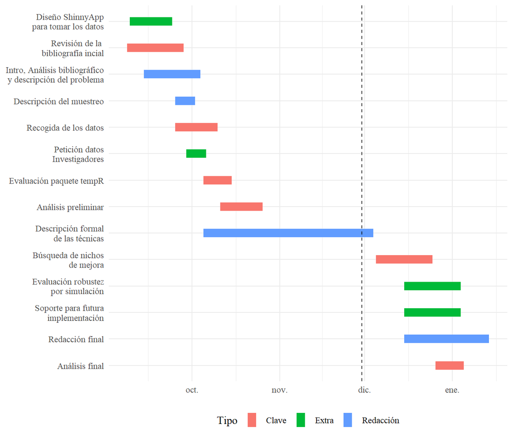

- Clave: Tareas necesarias
- Extra: Tareas no estrictamente necesarias o que pueden presentar alternativas
- Redacción: Tareas necesarias que se centran en el cuerpo del trabajo

### Evolución

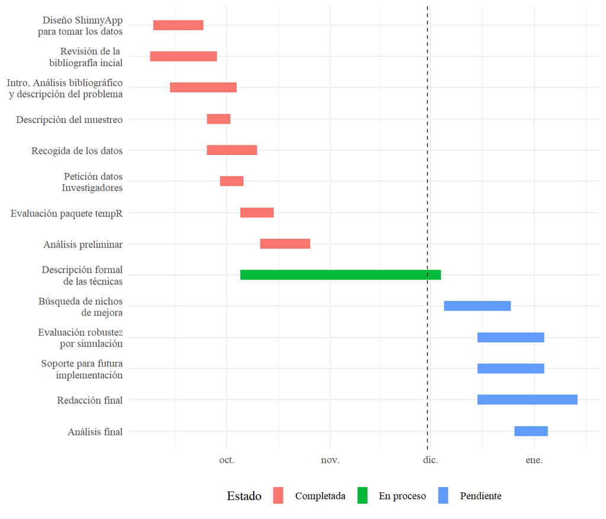

### Tabla

| Tarea | Tipo | Duración | Comienza | Finaliza | Estado |
| --- | --- | --- | --- | --- | --- |
| Revisión de la bibliografía incial | Clave | 20 | 2020-09-08 | 2020-09-28 | Completada |
| Diseño ShinnyApp para tomar los datos | Extra | 15 | 2020-09-09 | 2020-09-24 | Completada |
| Intro, Análisis bibliográfico y descripción del problema | Redacción | 20 | 2020-09-14 | 2020-10-04 | Completada |
| Recogida de los datos | Clave | 15 | 2020-09-25 | 2020-10-10 | Completada |
| Evaluación paquete tempR | Clave | 10 | 2020-10-05 | 2020-10-15 | Completada |
| Descripción del muestreo | Redacción | 7 | 2020-09-25 | 2020-10-02 | Completada |
| Análisis preliminar | Clave | 15 | 2020-10-11 | 2020-10-26 | Completada |
| Descripción formal de las técnicas | Redacción | 60 | 2020-10-05 | 2020-12-04 | En proceso |
| Petición datos Investigadores | Extra | 7 | 2020-09-29 | 2020-10-06 | Completada |
| Búsqueda de nichos de mejora | Clave | 20 | 2020-12-05 | 2020-12-25 | Pendiente |
| Análisis final | Clave | 10 | 2020-12-26 | 2021-01-05 | Pendiente |
| Redacción final | Redacción | 30 | 2020-12-15 | 2021-01-14 | Pendiente |
| Evaluación robustez por simulación | Extra | 20 | 2020-12-15 | 2021-01-04 | Pendiente |
| Soporte para futura implementación | Extra | 20 | 2020-12-15 | 2021-01-04 | Pendiente |

## Breve Descripción de las tareas

### Revisión bibliográfica

- Exposición de conceptos clave y objetivos del análisis sensorial
- Revisión de la bibliografía pertinente a la técnica TDS y similares (TCATA,TI).
  - Descripción de los datos que generan cada una y sus ventajas e inconvenientes.
  - Técnicas estadísticas empleadas

### Diseño ShinnyApp para tomar los datos

- Diseñar y desplegar una aplicación que sirva para tomar los datos (TDS,TCATA,TI ) Que sirva como alternativa a SensoMaker
- Que opere correctamente en móvil a ser posible
- Mejoras:
  - Reset de los valores tras la cata.
  - Elementos CSS.
  - Escoder boton de comenzar y añadir boton de finalizar.
  - Añadir explicaciones.
  - Limites de uso, Instancias, simulaciones y correción de errores.

### Intro, Análisis bibliográfico y descripción del problema

- Redacción de estos primeros apartados

### Recogida de los datos

- Se procede a Recoger los datos
- Necesidad de Reclutar

### Evaluación paquete tempR

- https://www.rdocumentation.org/packages/tempR/versions/0.9.9.16
- Evaluación del paquete y de las técnicas que recoge para ver si se adaptan a las vistas en la revisión bibliográfica.
- Evaluación de si opera con clases de objetos propias.
- Empleo de los datasets que incluye.
- Ver que funciones y operaciones de interés no están recogidas

### Descripción del muestreo

- Redacción y Descripción del procedimiento, la aplicación, la N etc

### Análisis preliminar

- Descriptivo básico
- Primer análisis empleando tempR o funciones propias

### Descripción formal de las técnicas

- Exposición formal y fundamentación teórica de las técnicas que se vayan a emplear.
- Dar apoyo gráfico a dichas exposiciones siempre que sea posible

### Obtención datos Investigadores

- Desconozco los entresijos del mundo académico y si esta petición suele caer en saco roto, sospecho que así es, pero otras fuentes de datos ya bien para evaluar posibles mejoras, ya bien para testear la robustez de las técnicas o simplemente para tratar de replicar los procedimientos y cerciorarnos de que el código esta implementado correctamente pueden ser de ayuda

### Búsqueda de nichos de mejora

- Búsqueda de aspectos a mejorar en las técnicas revisadas

### Análisis final

- En caso de poder mejorar el análisis preliminar.
- Se finaliza el análisis de los datos obtenidos

### Redacción final

- Se concluye el apartado del análisis de los datos
- Corrección global

### Evaluación robustez por simulación

- Empleo de técnicas de simulación para observar el comportamiento de las técnicas evaluadas

### Soporte para futura implementación

- Preparación de los Scripts de R y transformar la aplicación de shiny en un formulario html con un timmer(javascript o php quizás ) con objeto de su posible implementación en un futuro en el software tastebit.